# Final Presentation

Annika Kufrovich

January 24, 2019

## Courses I took

- Intermediate R
- Writing Functions in R
- Writing Efficient R Code
  - Looking at how to make sure the way you’re coding is the fastest in can be
  - When you’ve got a few hundred or a few thousand observations, this isn’t a big deal
  - When you have millions, you probably don’t want to run code for 2 weeks
- Parallel Programming
  - An extension to the *fast* or *efficient* side of R coding
  - Basically dividing up tasks between computer cores to reduce coding run time
  - Can’t be used on everything
- Working with geospatial data in R
  - Really cool stuff, but sp objects are very confusing
- Spatial Analysis in R with sf and raster
  - raster objects are gridded over large windows (elevation over an area could be in this)
  - sf objects are also like sp but much more intuitive, data frame with a list column to define shapes
  - Data associated with sf and sp objects are meant for statistics of defined areas like counties, states, or nations (areal statistics)
- Spatial Statitics
  - Focuses on points or “events” within a “window” (a polygon from an sf or sp object)
  - Tests for distribution of events and density plots
  - Not limited to this, also goes through more things with areal statistics, space-time data, and GLMs
- Analyzing US Census Data
  - Goes through how census data is structured and how to retrieve various kinds of census data
- The last 4 courses **all** went through making pretty plots with ggplot2

## Disclaimer and My data

Disclaimer: I have been working with my data for a while, already had a pretty pecific idea of what I wanted to do with thi data during ISP, and have been coding in R for semesters

Data: I have a big file of all registered voters in the state of Florida (This is public record because of Florida sunshine law). Each row is a registered voter and the variables are each a portion of the voter registration form. Variables I focus on are voter ID numbers, address, party affiliation, and active voter status. There are are roughly 30 more variable columns but we won’t worry about those.

## Quick look at my matching function

```r
library(dplyr)
```

Test Dataframes

```r
test1b <- data.frame(numbers = 1:8, letters = c("a", "b", "c", "d", "a", "b", "c", "d"))
test4b <- data.frame(numbers = 1:8, letters = c("a", "b", "c", "d", "a", "b", "c", "e"),
                     lon = c(12, 31, 64, 38, 89, 73, 91, 21))
```

Function

```r
matching_dfs_addcol <- function(newdf, olddf) {
  matching <- semi_join(olddf, newdf)
  matching_col <- matching %>%
    mutate(matched = TRUE)
  not_matching <- anti_join(newdf, olddf)
  not_matching_col <- not_matching %>%
    mutate(matched = FALSE)
  combined_df <- full_join(matching_col, not_matching_col)
  combined_df
}

new_func_test <- matching_dfs_addcol(test1b, test4b)
new_func_test
```

```
##   numbers letters lon matched
## 1       1       a  12    TRUE
## 2       2       b  31    TRUE
## 3       3       c  64    TRUE
## 4       4       d  38    TRUE
## 5       5       a  89    TRUE
## 6       6       b  73    TRUE
## 7       7       c  91    TRUE
## 8       8       d  NA   FALSE
```

## The Pains of Geocoding

```r
library(ggmap)
```

```r
#loading in liberty county data
new_lib <- read.delim("C:/Users/TeenieTiny/Desktop/2nd Year/Data/Voter_Registration_20181113/20181113_VoterDetail/LIB_20181113.txt", header=FALSE)

#making an address column to use for geocoding
new_lib_address <- new_lib %>%
  mutate(address = paste(V8, V10, "FL", sep = ", "))


#1st 1000 obs
nl_p1 <- new_lib_address %>%
  slice(1:1000)
nl_geocode_p1 <- nl_p1 %>%
  mutate_geocode(address, source = "dsk")


#2nd 1000 obs
nl_p2 <- new_lib_address %>%
  slice(1001:2000)
nl_geocode_p2 <- nl_p2 %>%
  mutate_geocode(address, source = "dsk")


#3rd 1000 obs
nl_p3 <- new_lib_address %>%
  slice(2001:3000)
nl_geocode_p3 <- nl_p3 %>%
  mutate_geocode(address, source = "dsk")


#4th 1000 obs
nl_p4 <- new_lib_address %>%
  slice(3001:4000)
nl_geocode_p4 <- nl_p4 %>%
  mutate_geocode(address, source = "dsk")


#last few hundred obs
nl_p5 <- new_lib_address %>%
  slice(4001:4626)
nl_geocode_p5 <- nl_p5 %>%
  mutate_geocode(address, source = "dsk")

#joining
nl_join <- full_join(nl_geocode_p5,
                     full_join(nl_geocode_p4,
                               full_join(nl_geocode_p3,
                                         full_join(nl_geocode_p1, nl_geocode_p2))))



#Then I realized I should have been using a function
geocoding <- function(df, col, seq) {
  sliced <- df %>%
    slice(seq)
  geocoded <- sliced %>%
    mutate_geocode(col, source = "dsk")
  geocoded
}

#ex <- geocoding(df = new_lib_address, col = address, seq = 1:3)
#ex$lon
#ex$lat
```

## Getting the shape of Liberty County

```r
library(sp)
library(sf)
library(tigris)
library(spatstat)
library(maptools)
```

```r
#retrieving sf object because it's easier to isolate liberty county this way
options(tigris_class = "sf")
fl_counties2 <- invisible(counties(state = "FL"))
```

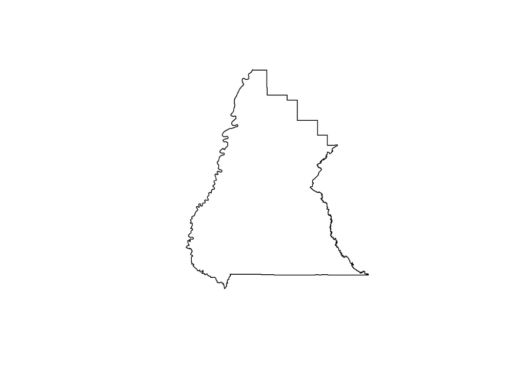

```r
#isolating liberty county
liberty <- fl_counties2 %>%
  filter(NAME == "Liberty")
plot(liberty$geometry)
```

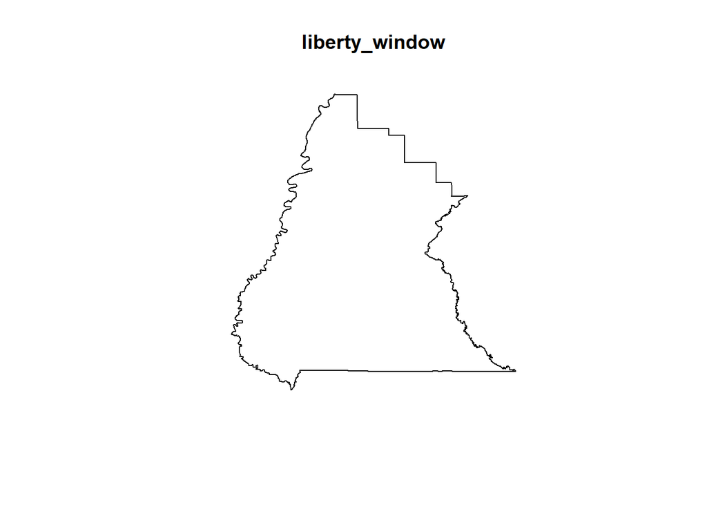

```r
#retrieving sp object in case sf object doesn't behave
libdf <- as.data.frame(liberty$geometry[[1]][[1]][[1]])
colnames(libdf) <- c("x", "y")

libPoly <- Polygon(libdf, hole = FALSE)
libPolys <- Polygons(list(libPoly), ID = "liberty")
libSpPoly <- SpatialPolygons(list(libPolys))

liberty_window <- as.owin(W = libSpPoly)
plot(liberty_window)
```

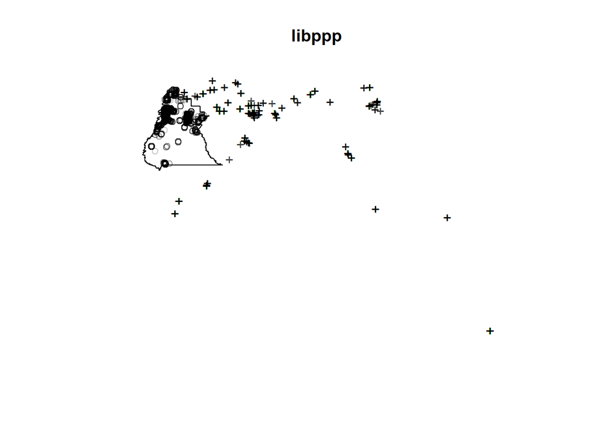

```r
nl_jxy <- nl_join %>%
  mutate(x = lon, y = lat) %>%
  mutate(party = ifelse(V24 == "DEM", "Democrat",
                        ifelse(V24 == "REP", "Republican", "NPA/Other"))) %>%
  mutate(active = V29)

nl_jxy$party <- as.factor(nl_jxy$party)

nl_min <- nl_jxy %>%
  select(x, y, party, active)

libppp <- ppp(nl_min$x, nl_min$y, window = liberty_window)
plot(libppp)
```

```r
libppp_act <- ppp(nl_min$x, nl_min$y, window = liberty_window, marks = nl_min$active)
summary(libppp_act)
```

```
## Marked planar point pattern:  4124 points
## Average intensity 20151.09 points per square unit
##
## *Pattern contains duplicated points*
##
## Coordinates are given to 6 decimal places
##
## Multitype:
##     frequency proportion intensity
## ACT      3878 0.94034920 18949.060
## INA       246 0.05965082  1202.029
##
## Window: polygonal boundary
## single connected closed polygon with 3945 vertices
## enclosing rectangle: [-85.15402, -84.54287] x [29.971399, 30.606393] units
## Window area = 0.204654 square units
## Fraction of frame area: 0.527
##
## *** 499 illegal points stored in attr(,"rejects") ***
```

```r
libppp_party <- ppp(nl_min$x, nl_min$y, window = liberty_window, marks = nl_min$party)
summary(libppp_party)
```

```
## Marked planar point pattern:  4124 points
## Average intensity 20151.09 points per square unit
##
## *Pattern contains duplicated points*
##
## Coordinates are given to 6 decimal places
##
## Multitype:
##            frequency proportion intensity
## Democrat        2906 0.70465570 14199.580
## NPA/Other        400 0.09699321  1954.518
## Republican       818 0.19835110  3996.990
##
## Window: polygonal boundary
## single connected closed polygon with 3945 vertices
## enclosing rectangle: [-85.15402, -84.54287] x [29.971399, 30.606393] units
## Window area = 0.204654 square units
## Fraction of frame area: 0.527
##
## *** 499 illegal points stored in attr(,"rejects") ***
```

## Some pretty plots

```r
library(ggplot2)
library(rnaturalearth)
library(rnaturalearthdata)
```

```r
#nl_sites <- st_as_sf(nl_join, coords = c("lon", "lat"),
#    crs = 4326, agr = "constant")
world <- ne_countries(scale = "medium", returnclass = "sf")
class(world)
```

```
## [1] "sf"         "data.frame"
```

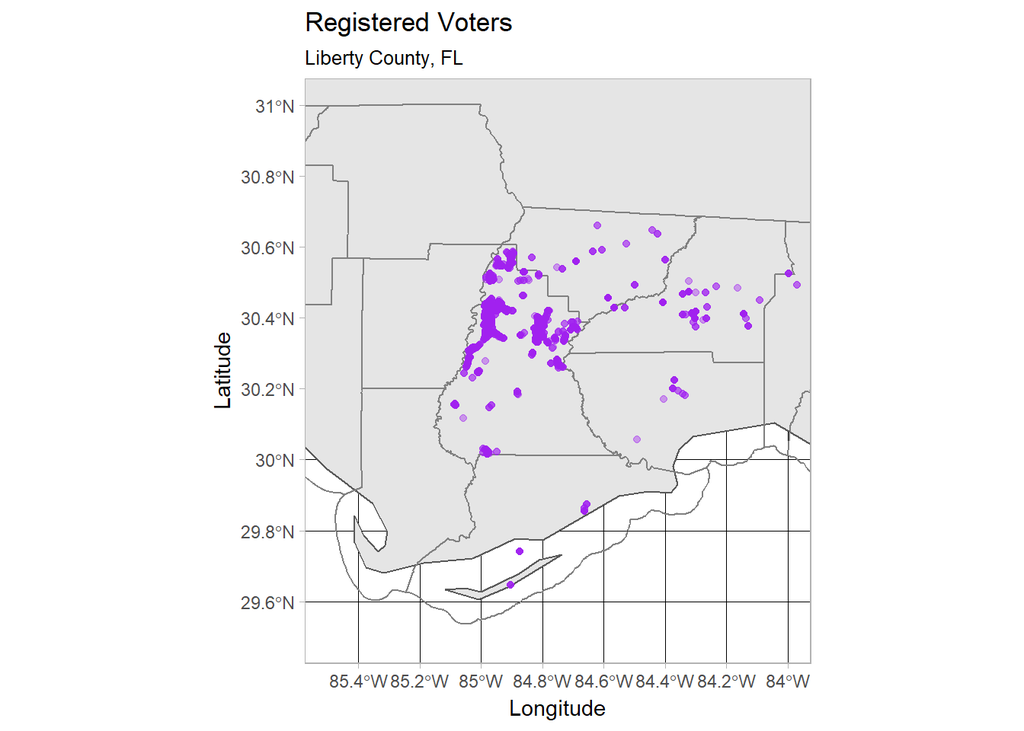

```r
ggplot(data = world) +
  geom_sf() +
  geom_sf(data = fl_counties2, fill = NA, color = gray(0.5)) +
  geom_point(data = nl_jxy, aes(x = lon, y = lat), color = "purple", alpha = 0.4) +
  coord_sf(xlim = c(-85.5, -84), ylim = c(29.5, 31)) +
  theme_light() +
  labs(x = "Longitude", y = "Latitude", title = "Registered Voters",
       subtitle = "Liberty County, FL")
```

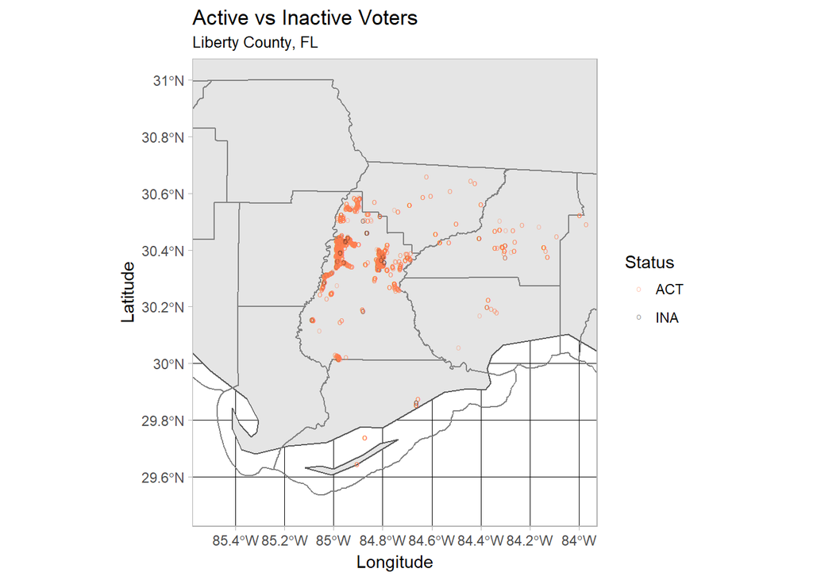

```r
ggplot(data = world) +
  geom_sf() +
  geom_sf(data = fl_counties2, fill = NA, color = gray(0.5)) +
  geom_point(data = nl_jxy, aes(x = lon, y = lat, col = active), shape = "o", alpha = 0.4) +
  coord_sf(xlim = c(-85.5, -84), ylim = c(29.5, 31)) +
  scale_color_manual(values = c("coral", "black")) +
  theme_light() +
  labs(x = "Longitude", y = "Latitude", title = "Active vs Inactive Voters",
       subtitle = "Liberty County, FL", colour = "Status")
```

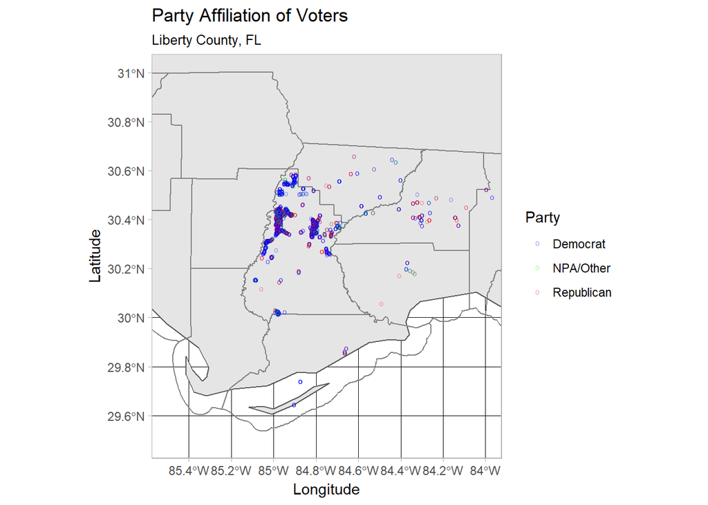

```r
ggplot(data = world) +
  geom_sf() +
  geom_sf(data = fl_counties2, fill = NA, color = gray(0.5)) +
  geom_point(data = nl_jxy, aes(x = lon, y = lat, col = party), shape = "o", alpha = 0.4) +
  coord_sf(xlim = c(-85.5, -84), ylim = c(29.5, 31)) +
  scale_color_manual(values = c("blue", "green", "red")) +
  theme_light() +
  labs(x = "Longitude", y = "Latitude", title = "Party Affiliation of Voters",
       subtitle = "Liberty County, FL", colour = "Party")
```

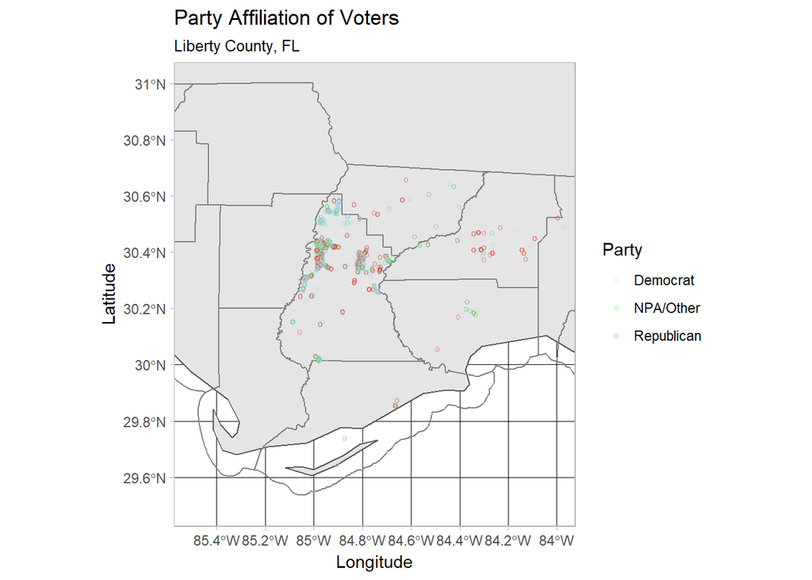

```r
ggplot(data = world) +
  geom_sf() +
  geom_sf(data = fl_counties2, fill = NA, color = gray(0.5)) +
  geom_point(data = nl_jxy, aes(x = lon, y = lat, col = party), shape = "o", alpha = 0.4) +
  coord_sf(xlim = c(-85.5, -84), ylim = c(29.5, 31)) +
  scale_color_manual(values = c("light blue", "green", "red")) +
  theme_light() +
  labs(x = "Longitude", y = "Latitude", title = "Party Affiliation of Voters",
       subtitle = "Liberty County, FL", colour = "Party")
```

## Density plots

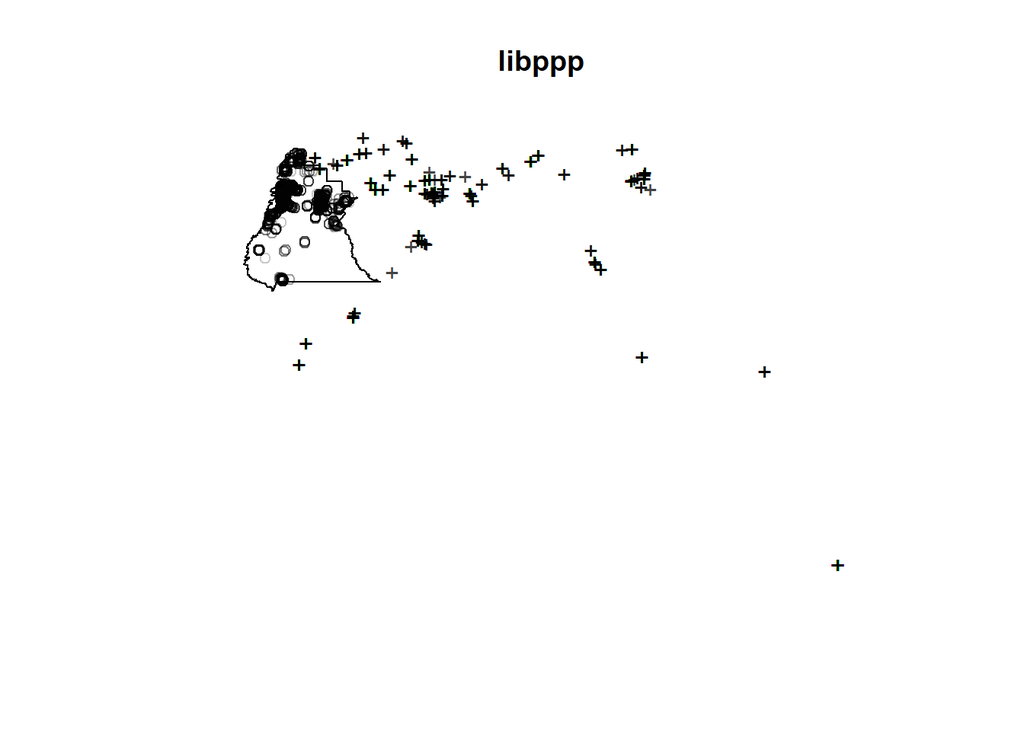

```r
plot(libppp)
```

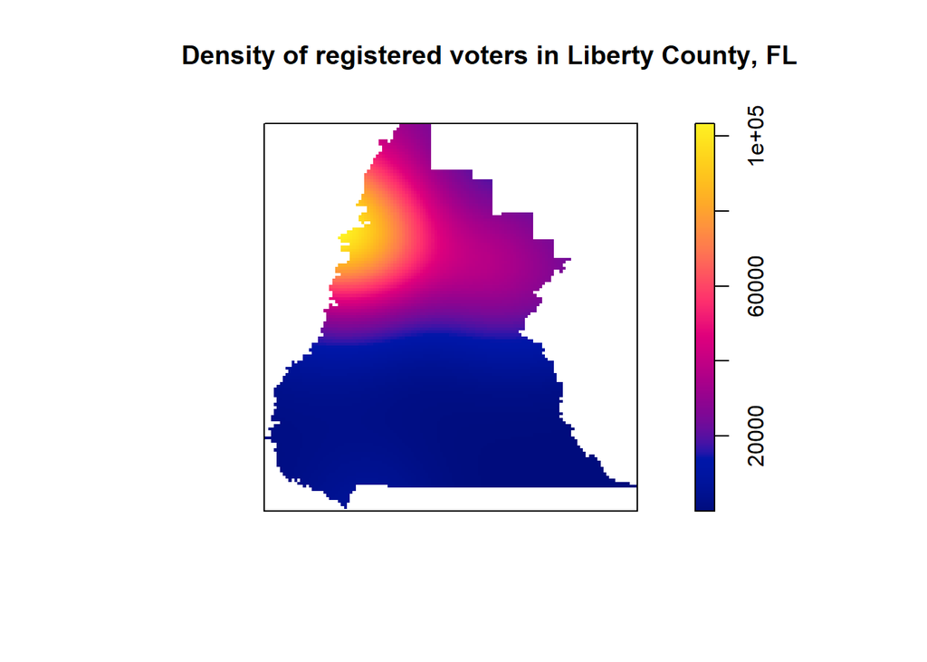

```r
gen_dens <- plot(density(libppp), main = "Density of registered voters in Liberty County, FL")
```

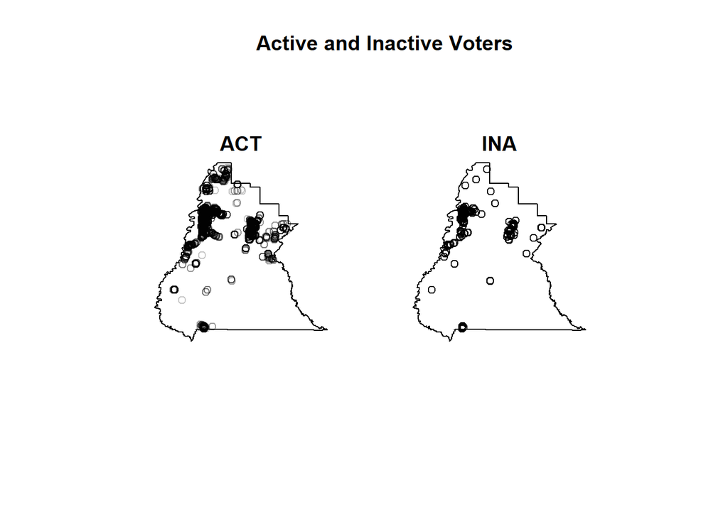

```r
invisible(gen_dens)

active_splits <- split(libppp_act)
bas_act <- plot(active_splits, main = "Active and Inactive Voters")
```

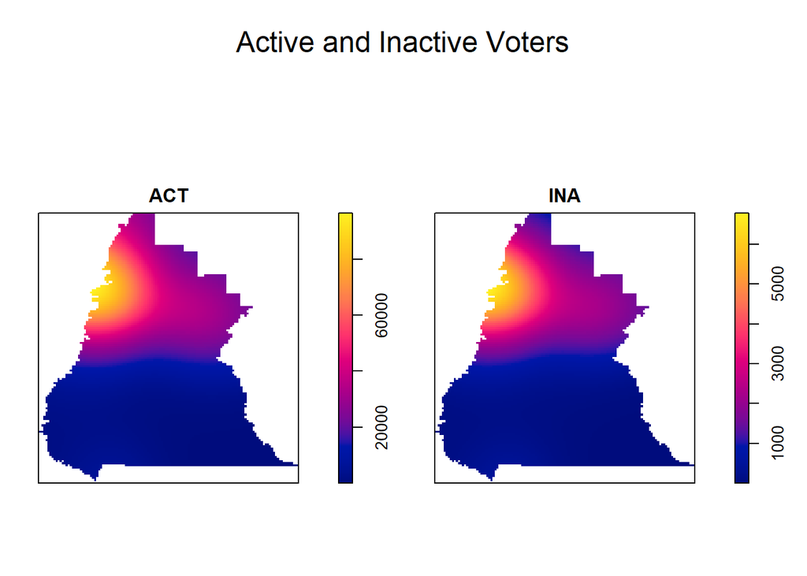

```r
invisible(bas_act)

dens_act <- density(active_splits)
plot(dens_act, main =  "Active and Inactive Voters")
```

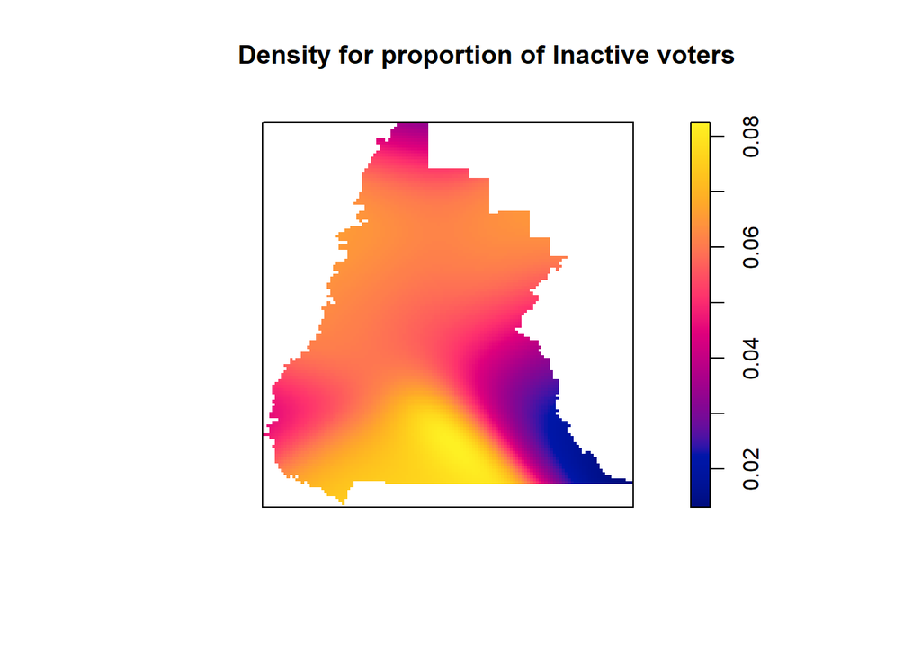

```r
frac_dens_act <- dens_act[[2]] / (dens_act[[1]] + dens_act[[2]])
plot(frac_dens_act, main = "Density for proportion of Inactive voters")
```

## Future Research

- Figure out why so many points were outside liberty county and somw were not gecoded
- Expand to other counties in Florida, Florida as a whole
- Use data for various GLM’s
- Work on more accurate and more efficient geocoding